# Transformada de Laplace

Un problema de mezclas con alimentadores controlados mediante válvulas. En el instante $t=0$ se abre la válvula A, para transferir 6 litros/minuto de una solución salina con 0.4 kg de sal por litro. Cuando $t=10$ minutos, la válvula A se cierra y se abre la válvula B y comienzan a pasar 6 litros/minuto de solución salina con una concentración de 0.2 kg/litro. En un principio había 30 kg de sal disueltos en 1000 litros de agua en el tanque. La válvula de salida C, que vacía al tanque a razón de 6 litros/minuto, mantiene el contenido del tanque a volumen constante. Si la solución se mantiene bien revuelta, determine la cantidad de sal en el tanque para cada $t > 0$.

[figure not shown]

Si notamos a $x(t)$ como la cantidad de sal (en kilogramos) en el tanque en el tiempo t. Así $\frac{x(t)}{100}$ es la antidad de concentración.

- De esta forma el contenido que entra en kg/min

Válvlula A $0.4 kg/L \times 6L/min=2.4 kg/min$

Válvlula B $0.2 kg/L \times 6L/min=1.2 kg/min$

$$ g(t)=\left\{\begin{array}{ll}2.4 kg/min&\text{ si } 0<t<10 &\text{ válvula A}\\1.2 kg/min&\text { si } t\geq10 &\text{válvula B}\end{array}\right.$$

- Contenido que sale en kg/min

$$\frac{x(t) kg}{100 L}\times \frac{6 L}{min}=\frac{3 kg}{500 min}.$$

De esta forma la ecuación queda

$$\frac{d}{dt}x(t)=g(t)-\frac{3x(t)}{500},$$

sujeto a la condición inicial $x(0)=30$

[figure not shown]

# Transformada de laplace

## Definción

Una función $f(t)$, definida en $[0,\infty)$ su trnasformada de Laplace es

$$ℒ[𝑓](𝑠) =F(s):=\int_0^{\infty} e^{-st}f(t)dt.$$

Note que es una integral impropia, así

$$\int_0^{\infty} e^{-st}f(t)dt=\lim_{N\to \infty}\int_0^Ne^{-st}f(t)dt.$$

### Ejemplo

Cálcular la transformada de laplace de $f(t)=1$, para $t>0$

$$F(s)=\int_0^{\infty} e^{-st}f(t)dt=\int_0^{\infty} e^{-st}dt=\lim_{N\to \infty}\int_0^Ne^{-st}dt$$$$=\lim_{N\to\infty}\frac{-e^{-st}}{s}\Big|_{t=0}^{t=N}=\lim_{N\to\infty}\Big[\frac{1}{s}-\frac{e^{-sN}}{s}\Big]$$

así $$F(s)=\frac{1}{s},\text{ para }s>0$$

## Ejercios

Determinar la transformada de Laplace,$\mathscr{L}[f](s)$ para las siguientes funciones

- $f(t)=e^{2t}$
- $f(t)=\sin(t)$

$f(t)= \left\{ \begin{array}{lcc} 5 & si & t \leq 2 \\ \\ 0 & si & 2 < t < 5 \\ \\ 4t-15 & si & t \geq 5 \end{array} \right.$

## Propiedad de linealidad de la transformadade Laplace

Sean $f_1$ y $f_2$ funciones cuyas transformadad e laplace existe para $s>\alpha$ y sea $c$ constante. Entonces, para $s>\alpha$

\begin{equation} \mathscr{L}[f_1+f_2](s)=\mathscr{L}[f_1](s) +\mathscr{L}[f_2](s). %\label{eq:laplace1} \tag{1} \end{equation}\begin{equation} \mathscr{L}[cf_1](s)=c\mathscr{L}[f_1](s). %\label{eq:laplace2} \tag{2} \end{equation}

## Ejemplo

Usando la propiedad de linealidad calcular la trnasformada de laplace de

- $f(t)=5$
- $f(t)=2+5e^{4t}$
- $f(t)=t^2+5e^{4t}\sin(2t)$

## Existencia de la transformadad de Laplace

#### Definición

Una función $f(t)$ es continua por partes en un intervalo finito $[a,b]$ si $f(t)$ es continua en cada punto de $[a,b]$, exepto en un número finito de puntos dende $f(t)$ tiene una discontinuidad de salto.

Una función $f(t)$ es **continua por partes en $[a,b]$** si $f(t)$ es continua por partes en $[0,N]$ para toda $N>0$

#### Ejemplo

$$f(t)=\left\{ \begin{array}{lcc} t & si & 0 < t < 1 \\ \\ 2 & si & 1 < t < 2 \\ \\ (t-1)^2 & si & 2 \leq t \leq 3 \end{array} \right.$$

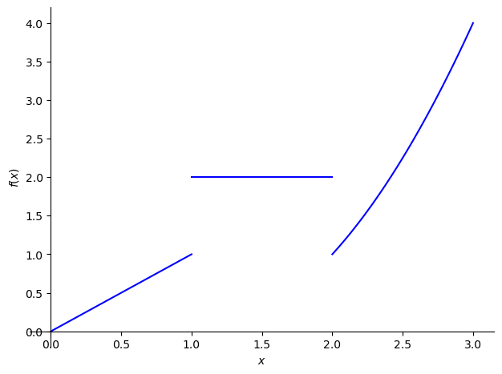

```python
toggle_cell_code("1")
from sympy import symbols
from sympy.plotting import plot

x = symbols('x')

p1=plot((x, (x, 0, 1)), (2, (x, 1, 2)),((x-1)**2, (x, 2,3)),line_color="blue", show=False)
p1.legend = False
p1.show()
 #line_color="cyan", show=False)
```

## Definción de orden exponencial

Una $f(t)$ es de **orden exponencial $\alpha$** si existen constantes positivas $T$ y $M$ tales que

\begin{equation} |f(t)|\leq Me^{\alpha t}\text{ para todo }t\geq T %\label{eq:laplace3} \tag{3} \end{equation}

## Ejemplo

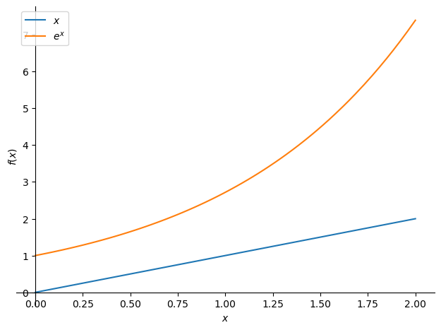

```python
toggle_cell_code("2")
from sympy import symbols
from sympy.plotting import plot
import sympy as sy

x = symbols('x')
n=1
k=sy.factorial(n)
p1=plot((x**n, (x, 0, 2)), (k*sy.exp(x), (x, 0,2)),show=False)
p1.legend = True
p1.show()
```

$$ \lim_{t\to \infty}\frac{t^2}{2e^{t}}=\lim_{t\to \infty}\frac{2t}{2e^{t}}=\lim_{t\to \infty}\frac{1}{e^{t}}=0$$

## Teorema condiciones y existencia de la Transformada de Laplace

Si f(t) es continua por partes en $[0, \infty)$ y de orden exponencial $\alpha$, entonces $\mathscr{L}[f](s)$ existe para $s>\alpha$ .

$$ \begin{array}{lrr} f(t) & F(s) & \text{condiciones} \\ 1 & \frac{1}{s} & s>0 \\ e^{at} & \frac{1}{s-a} & s>0 \\ t^n,\text{ para }n=1,\dots & \frac{n!}{s^{n+1}} & s>0\\ \sin(bt) & \frac{b}{s^2+b^2} & s>a\\ \cos(bt) & \frac{s}{s^2+b^2} & s>a\\ e^{at}\sin(bt) & \frac{b}{(s-a)^2+b^2} & s>a\\ e^{at}\cos(bt) & \frac{s-a}{(s-a)^2+b^2} & s>a \end{array}$$

## Ejercicios

1. Encuentre las transformaciones
   - $t^2+e^t\sin(2t)$
   - $t^2-e^{2t}$
   - $e^{7t}sin^2(t)$ use la identidad de angulos medios $\sin^2(x)=\frac{1-\cos(2x)}{2}$
   - $f(t)= \left\{ \begin{array}{lcc} \frac{1}{t-2} & si & 0< t \leq1 \\ 1 & si & 1 < t \leq 2 \\ t & si & 2 < t \leq 10 \end{array}\right.$
2. ¿Cuáles de las siguinetes funciones son de orden exponencial?
   - $t^3\sin(t)$
   - $\frac{1}{t^2 +1}$
   - $3-e^{t^2}+\cos(4t)$
3. De la tabla de transformaciones, $F(s)$ que se puede decir de $\lim_{s\to\infty}F(s)$

# Propiedades de Transformadad e Laplace

## Propiedad de translación,

**Teorema** Sea la trnasformadade Laplace $\mathscr{L}[f](s)=F(s)$ existe para $s>\alpha$ entonces

$$\mathscr{L}[e^{at}f(t)](s)=F(s-a)$$

**Ejemplo** Cálcular la trnasformada de $f(t)=e^{5t}\sin(3t)$,

note que

$$\mathscr{L}[\sin(3t)](s)=\frac{3}{s^2+9}$$

Luego

$$\mathscr{L}[e^{5t}\sin(3t)](s)=\frac{3}{(s-5)^2+9}$$

## Transformadade Laplace de la derivada

**Teorema** Sea $f(t)$ continua en $[0,\infty]$ y $f'(t)$ continua por partes en $(,\infty)$, ambas de orden expnencial $\alpha$. Entonces $s>\alpha$

$$\mathscr{L}[f'(t)](s)=s\mathscr{L}[f(t)](s)-f(0).$$

**Ejemplo**

Use el hecho de $\mathscr{L}[\sin(bt)](s)=\frac{b}{s^2+b^2}$ para calcular $\mathscr{L}[cos(bt)](s)$.

Sea $f(t)=\sin(bt)$, entonces $f(0)=0$ y $f'(t)=b\cos(bt)$, por lo tanto

$$\mathscr{L}[f'(t)](s)=s\mathscr{L}[f(t)](s)-f(0)$$$$\mathscr{L}[b\cos(bt)](s)=s\mathscr{L}[\sin(bt)](s)-0$$$$b\mathscr{L}[\cos(bt)](s)=s\frac{b}{s^2+b^2}$$$$\mathscr{L}[\cos(bt)](s)=\frac{s}{s^2+b^2}$$

## Teoremade la derivada de orden superior

Sean $f(t)$ y $f^{(n)}(t)$ continuas en $[0,\infty)$ y $f^{(n)}(t)$ continua por partes en $(0,\infty)$, ambas de orden exponencial $\alpha$. Entonces $s>\alpha$

$$\mathscr{L}[f^{(n)}(t)](s)=s^n\mathscr{L}[f(t)](s)-s^{n-1}f(0)-s^{n-2}f'(0)-\cdots-f^{n-1}(0). $$

## Derivadas de la transformada de Laplace

Sea $F(s)=\mathscr{L}[f(t)](s)$ y supongamos que $f(t)$ es continua por partes en $[0,\infty)$ de orden exponencial $\alpha$. Entonces para $s>\alpha$

$$\mathscr{L}[t^nf(t)](s)=(-1)^n\frac{d^nF}{ds^n}(s)$$

## Ejemplo

Determinar la transformada de Laplace de $f(t)=\sin(bt)$

Sabemos que $F(s)=\mathscr{L}[\sin(bt)](s)=\frac{b}{s^2+b^2}$, entonces

$$\frac{dF}{ds}(s)=\frac{-2bs}{(s^2+b^2)^2}$$

Por tanto

$$\mathscr{L}[t\sin(bt)](s)=(-1)\frac{dF}{ds}(s)=\frac{2bs}{(s^2+b^2)^2}$$

## Tabla de propiedades

$$\mathscr{L}[f+g](s)=\mathscr{L}[f](s)+\mathscr{L}[g](s)$$$$\mathscr{L}[cf(t)](s)=c\mathscr{L}[f(t)](s)$$$$\mathscr{L}[e^{at}f(t)](s)=\mathscr{L}[f(t)](s-a)$$$$\mathscr{L}[f'(t)](s)=s\mathscr{L}[f(t)](s)-f(0)$$$$\mathscr{L}[f^{(n)}(t)](s)=s^n\mathscr{L}[f(t)](s)-s^{n-1}f(0)-s^{n-2}f'(0)-\cdots-f^{(n-1)}(0)$$$$\mathscr{L}[t^nf(t)](s)=(-1)^n\frac{d^nF}{ds^n}(s)$$

## Determinar la transformada de Laplace de las siguientes funciones

1. $t^2+e^t\sin(2t)$
2. $e^{7t}\sin^2t$
3. $(++e^{-t})^2$
4. $2t^2-t+\cos(4t)$
5. $\sin(2t)\sin(5t)$
6. $\sin(2t)\cos(5t)$
7. $\cos(2t)\cos(5t)$

## Translación en t

Sea $c>0$ y $f(t)$ continua partes en $[0,\infty)$, entonces

$$g(t)= \left\{ \begin{array}{lcc} 0 & si & 0< t <c \\ \\ f(t-c) & si & c < t \end{array} \right.$$

tiene trnasformada

$$\mathscr{L}[g(t)](s)=e^{-cs}\mathscr{L}[f(t)](s)$$

# Transformada Inversa de Laplace

Dada una función $F(s)$ entonces entonces existe una función $f(t)$ que sea continua en $[0,\infty)$ definida por

$$f(t)=\mathscr{L}[f(t)](s)=F(s)$$

entonces decimos que $f(t)$ es la transformada inversa de Laplace de $F(s)$ y usamos la notación

$$f(t)=\mathscr{L}^{-1}[F(s)]$$

## Ejemplo

Determinar $f(t)=\mathscr{L}^{-1}[F(s)](t)$ de $$F(s)=\frac{1}{s^2+1}$$

como $\mathscr{L}[\sin(t)](s)=\frac{1}{s^2+1}$ entonces $$f(t)=\mathscr{L}^{-1}[\frac{1}{s^2+1}](t)=\sin(t)$$

## Ejemplo

$$F(s)=\frac{2}{s^3}$$

como

$$\mathscr{L}^{-1}[\frac{2}{s^3}](t)=\mathscr{L}^{-1}[\frac{2!}{t^3}](t)=t^2.$$

## Ejemplo

$$F(s)=\frac{s-1}{s^2-2s+5}$$$$\mathscr{L}^{-1}\Big[\frac{s-1}{s^2-2s+5}\Big](t)=\mathscr{L}^{-1}\Big[\frac{s-1}{(s-1)^2+2^2}\Big](t)=e^2\cos(2t)$$

# Propiedad de linealidad de la transformada inversa de Laplace

Suponga que $\mathscr{L}^{-1}[F(s)](t)$ y $\mathscr{L}^{-1}[G(s)](t)$ existen y $c$ un escalar, entonces

$$\mathscr{L}^{-1}[cF(s)](t)=c\mathscr{L}^{-1}[F(s)](t)$$$$\mathscr{L}^{-1}[F(s)+G(s)](t)=\mathscr{L}^{-1}[F(s)](t)+\mathscr{L}^{-1}[G(s)](t)$$

## Ejemplo

Determinar

$$\mathscr{L}^{-1}\Big[\frac{5}{s-6}-\frac{6s}{s^2+9}+\frac{3}{2s^2+8s+10}\Big](t)$$$$\mathscr{L}^{-1}\Big[\frac{5}{s-6}\Big](t)-\mathscr{L}^{-1}\Big[\frac{6s}{s^2+9}\Big](t)+\mathscr{L}^{-1}\Big[\frac{3}{2s^2+8s+10}\Big](t)$$$$5\mathscr{L}^{-1}\Big[\frac{1}{s-6}\Big](t)-6\mathscr{L}^{-1}\Big[\frac{s}{s^2+3^2}\Big](t)+\frac{3}{2}\mathscr{L}^{-1}\Big[\frac{1}{s^2+4s+5}\Big](t)$$

como

$$\mathscr{L}^{-1}\Big[\frac{1}{s-6}\Big](t)=e^{6t}$$$$\mathscr{L}^{-1}\Big[\frac{s}{s^2+3^2}\Big](t)=\cos(3t)$$$$\mathscr{L}^{-1}\Big[\frac{1}{s^2+4s+5}\Big](t)=\mathscr{L}^{-1}\Big[\frac{1}{(s+2)^2+1}\Big](t)=e^{-2t}\sin(t)$$

Luego $$\mathscr{L}^{-1}\Big[\frac{5}{s-6}-\frac{6s}{s^2+9}+\frac{3}{2s^2+8s+10}\Big](t)=5e^{6t}-6\cos(3t)+\frac{3}{2}e^{-2t}\sin(t)$$